# Results_1

```python
from constants import *
from utility_functions import *
from plot_functions import *
from decoding_approaches import *
import numpy as np
from matplotlib import pyplot as plt
from scipy.stats import vonmises, poisson
import math
```

```python
# importlib module
```

#### This trajectory time is something that I am not sure how & where to use; Maybe T should be == num_positions ?

```python
print('Time steps (s)')
# print('Spike count time window:',sc_time_step)
print('Unit time for OU process:',dt)
```

```
Time steps (s)
Unit time for OU process: 0.1
```

### Question about the plot

Which of those time steps is better ? I would say the uncommented one, because indices represent points in time

Generating inputs

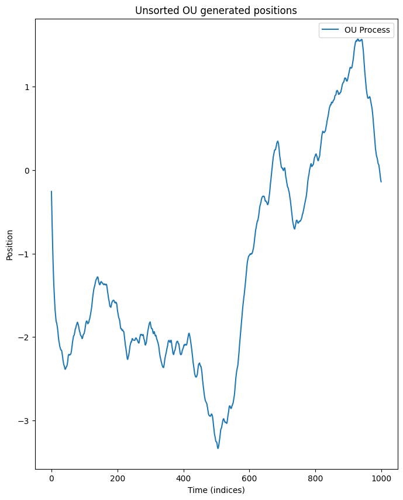

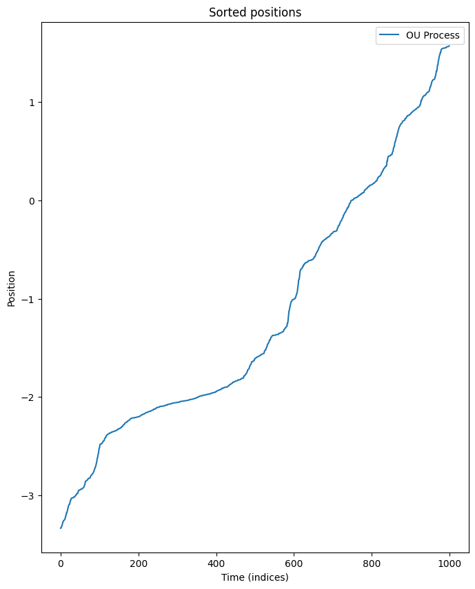

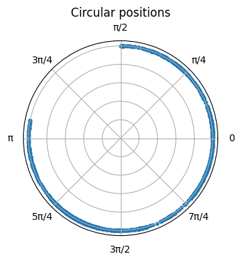

```python
# OU process
#TODO: look @ the distribution of x (with same intial conditions) over 10^4 trials (it should be uniform)
x0 = np.random.randn()
v0 = np.random.randn()
positions = get_OU_inputs(x0, v0, num_positions, dt, tau, mu, sigma)
plt_positions_uncirculated(positions, num_positions, dt, title='Unsorted OU generated positions')
# !!!!
positions = np.sort(positions)
plt_positions_uncirculated(positions, num_positions, dt, title='Sorted positions')

# Mapping positions on a circle
circ_positions = circular_positions(positions, num_positions)
plt_circulated_pos(circ_positions)
```

```python
print(np.median(positions))
print(np.mean(positions))
```

```
-1.60949717
-1.15172961128
```

#### Phases

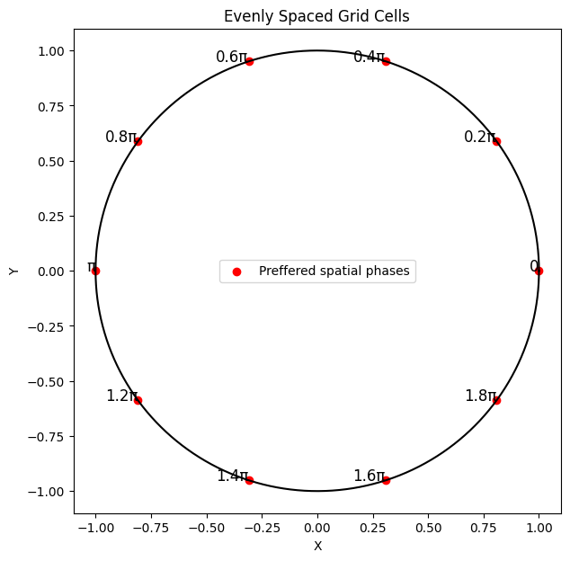

```python
# Preffered phase of a grid cell
phases = get_evenly_spaced_phases(num_neurons, plot=True)
```

### Generating Firing rates

```python
# For every neuron, for each position - a vector of spike rates is generated -- single number per position

# Comparing firing rates for circulated positions and uncirculated
firing_rates_p = np.zeros((num_neurons, num_positions))
firing_rates_cp = np.zeros((num_neurons, num_positions))
```

```python
for pos in range(num_positions):
    firing_rates_p[:, pos] = compute_firing_rates_VM(positions[pos], phases, scaling, kappa, max_firing_rate)
    firing_rates_cp[:, pos] = compute_firing_rates_VM(circ_positions[pos], phases, scaling, kappa, max_firing_rate)
```

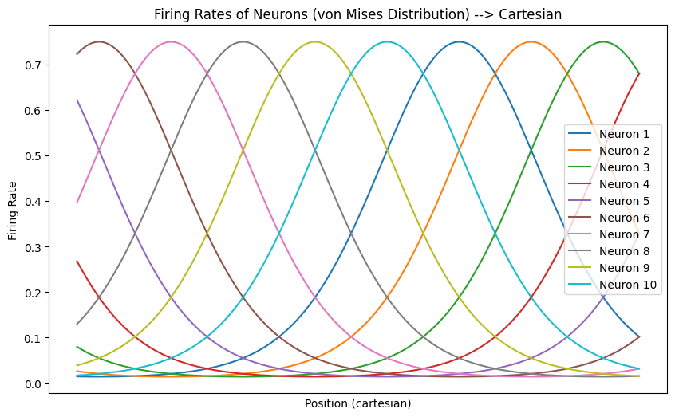

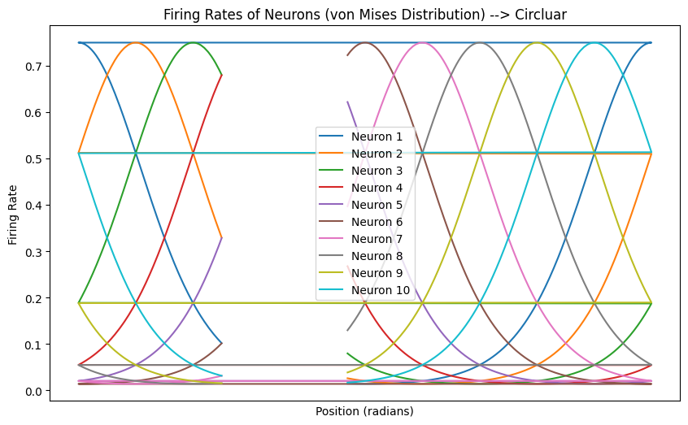

```python
plt_firing_rates_VM(positions, num_neurons, firing_rates_p, num_positions, title='Cartesian')
plt_firing_rates_VM(circ_positions, num_neurons, firing_rates_cp, num_positions, title='Circluar')
```

Vertical sum of firing rates is the same, that's why the vertical generation of spike counts doesn't make sense at all  
I suppose the vertical firing rate sum is almost the same for every position, bc the positions are continuous  
Consequentially, the sum of spikes (generated vertically) will always be the same  
Also the spike vectors are completely the same so this cannot be the right approach

### DECODING POSITIONS

Indices = time points  
Time window for counting spikes is 5 (so I take FIRST 5 succesive points for generating a FIRST count vector)

```python
sc_time_step
```

```
5
```

```python
# !! num_positions must be dividible w/ sc_time_step bc of reshaping the original_positions
num_time_windows = math.ceil(num_positions/sc_time_step)
spike_counts = np.zeros((num_time_windows, num_neurons))
fr_sums = np.zeros((num_time_windows, num_neurons))
decoded_positions = np.zeros(num_time_windows)
tw_original_positions = circ_positions.reshape(num_time_windows, -1)
```

```python
for time_window in range(num_time_windows):
    for neuron in range(num_neurons):                                       # sliding through the positions
        fr_sums[time_window][neuron] = sum(firing_rates_cp[neuron][ time_window*sc_time_step : (time_window+1)*sc_time_step] )
        proba = np.random.random()
        spike_counts[time_window][neuron] = poisson.rvs(fr_sums[time_window][neuron], sc_time_step) if proba > dropout else 0
```

Pipline for every decoding approach

1. approach_name
2. for time_window: decoded_positions[time_window] = approach_algorithm(spike_counts[time_window])
3. test_decoded_pos_rnd_index(tw_original_positions, decoded_positions, approach_name:str)
4. mse, square_diff = MSE_decoded_original_pos(decoded_positions, original_positions)
5. plt_square_diff(mse, squared_diff, approach_name:str, skip_ticks_step=10)
6. plot_spike_count_statistics_vs_squared_diff(mse, squared_diff, approach_name:str, skip_ticks_step=10) / plt_scatter_sqd_sc(spike_counts, squared_diff)
7. plt_circular_distance(decoded_positions, tw_original_positions, approach_name:str, skip_ticks_step=10)
8. plt_real_vs_decoded_trajectory(decoded_positions, tw_original_positions, approach_name, sc_time_step=sc_time_step)
9. plt_decoded_positions(tw_original_positions, decoded_positions, circ_positions, sc_time_step, num_time_windows_limit, tw_bounds:bool, approach_name:str)

""""""""""""""""""""""""""""""""""""""""""""""""""""""""""""""""""""""""""""""""""""

#### Basic approach for decoding positions -- phase of the winner

```python
approach_name = 'Basic'
decode_positions(decoded_positions, basic_approach, spike_counts, phases)
```

```
Random chosen tw: 18
Circ Mean original position for given tw (normalized radians): 3.614392097854167
Decoded position (normalized radians): 3.7699111843077517
```

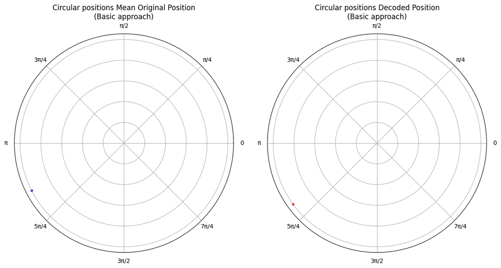

```python
test_decoded_pos_rnd_index(tw_original_positions, decoded_positions, approach_name = approach_name)
```

```python
# MSE
mse, squared_diff = MSE_decoded_original_pos(decoded_positions, tw_original_positions)
```

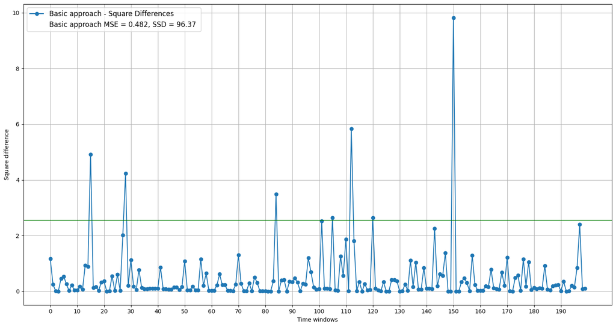

```python
# def plt_square_diff(mse, squared_diff, approach_name:str, threshold_meth = 'min_max', k = None, skip_ticks_step=10):
plt_square_diff(mse, squared_diff, approach_name=approach_name, threshold_meth = 'mean_std', k=2)
```

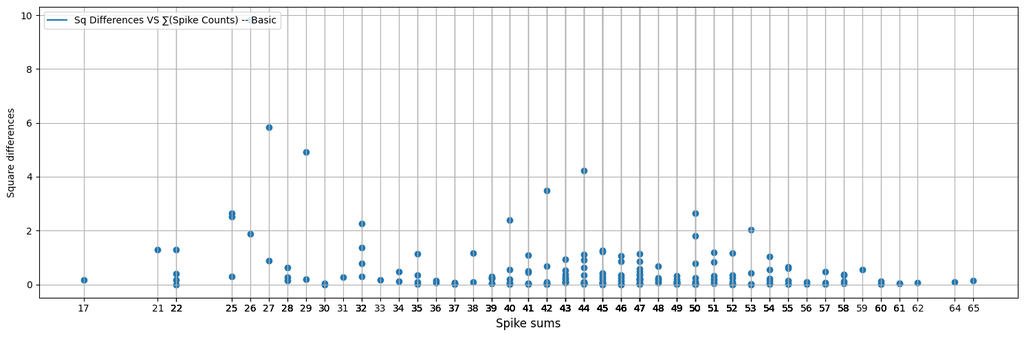

```python
# plot_spike_count_statistics_vs_squared_diff(squared_diff, spike_counts, threshold_meth = 'mean_std', k = 2)
plt_scatter_sqd_sc(spike_counts, squared_diff, approach_name)
```

```python
#TODO: this still doesn't fucking work !!!!
# plt_circular_distance(decoded_positions, tw_original_positions, approach_name)
```

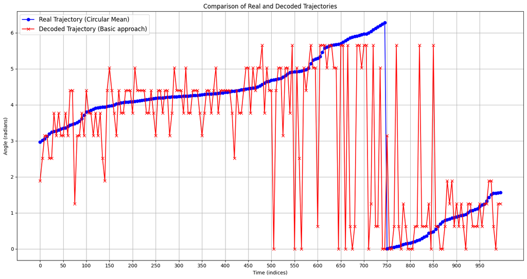

```python
plt_real_vs_decoded_trajectory(decoded_positions, tw_original_positions, approach_name, skip_ticks_step=10)
```

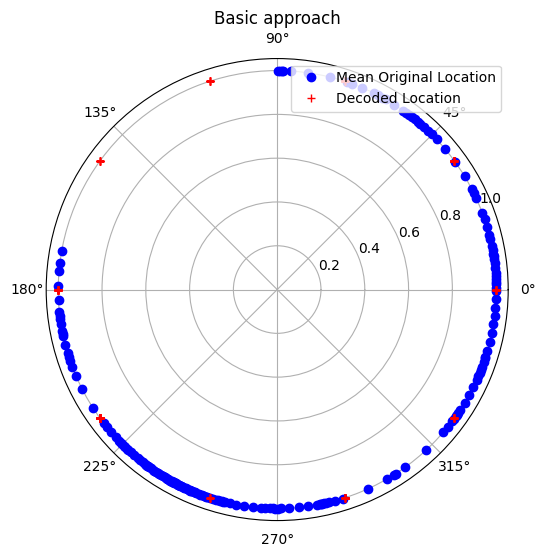

```python
# num_tw_limit is how we make sure that decoded locations don't overlap
plt_decoded_positions_cmp_mean_og(tw_original_positions, decoded_positions, circ_positions, sc_time_step, num_time_windows_limit=num_time_windows, tw_bounds = False, approach_name=approach_name)
```

""""""""""""""""""""""""""""""""""""""""""""""""""""""""""""""""""""""""""""""""""""""""""""""""""""""""""""""""""""""""""

#### Approach2: weighted phases for decoding positions

```python
approach_name = 'Weighted sum'
decode_positions(decoded_positions, weighted_sum_approach, spike_counts, phases)
```

```
Random chosen tw: 59
Circ Mean original position for given tw (normalized radians): 4.226569675200061
Decoded position (normalized radians): 2.955948241588464
```

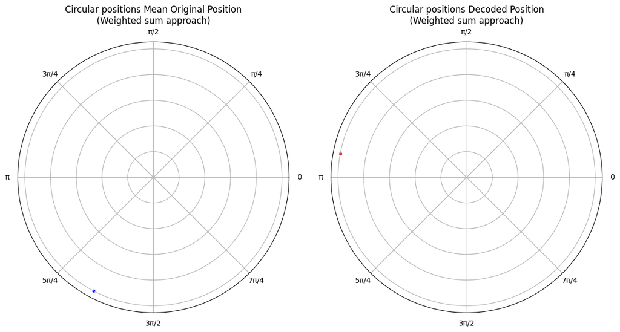

```python
test_decoded_pos_rnd_index(tw_original_positions, decoded_positions, approach_name = approach_name)
```

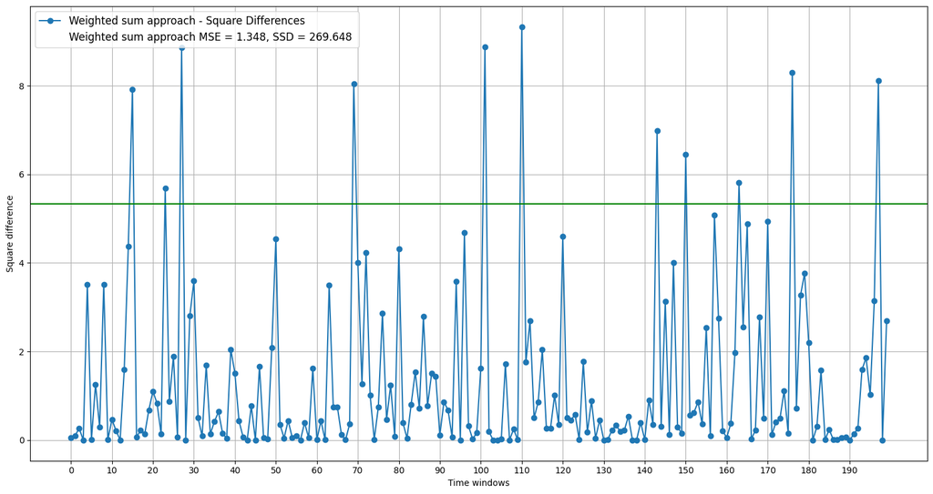

```python
mse, squared_diff = MSE_decoded_original_pos(decoded_positions, tw_original_positions)
plt_square_diff(mse, squared_diff, approach_name=approach_name, threshold_meth = 'mean_std', k=2)
```

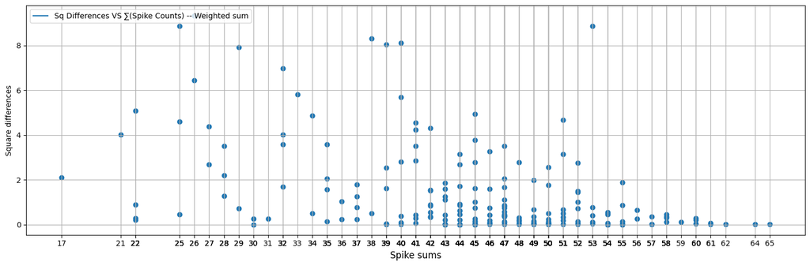

```python
# plot_spike_count_statistics_vs_squared_diff(squared_diff, spike_counts, threshold_meth = 'mean_std', k = 2)
plt_scatter_sqd_sc(spike_counts, squared_diff, approach_name)
```

```python
# plt_circular_distance(decoded_positions, tw_original_positions, approach_name)
```

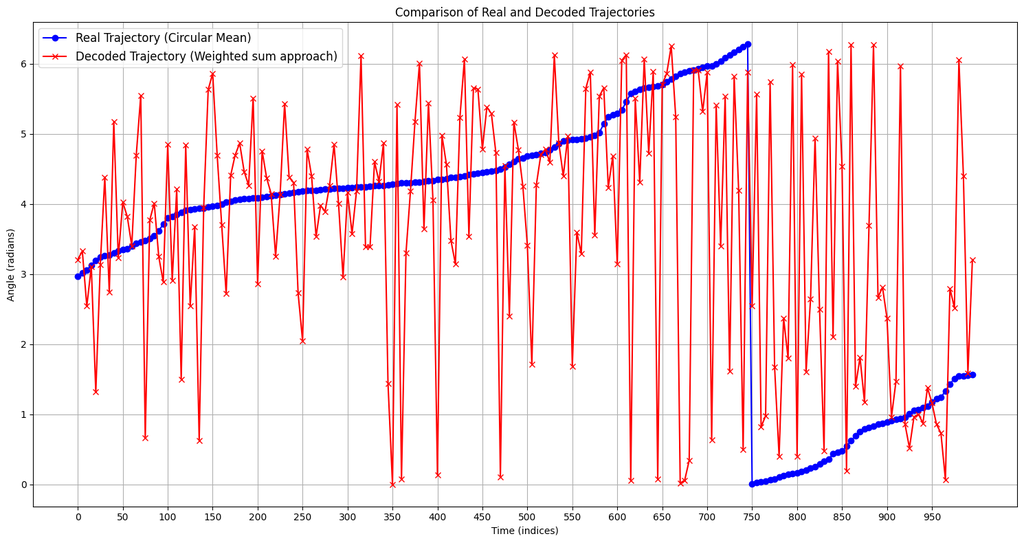

```python
plt_real_vs_decoded_trajectory(decoded_positions, tw_original_positions, approach_name, skip_ticks_step=10)
```

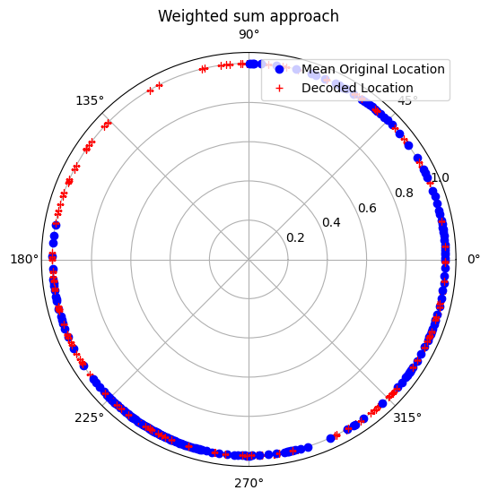

```python
plt_decoded_positions_cmp_mean_og(tw_original_positions, decoded_positions, circ_positions, sc_time_step, num_time_windows_limit=num_time_windows, tw_bounds = False, approach_name=approach_name)
```

""""""""""""""""""""""""""""""""""""""""""""""""""""""""""""""""""""""""""""""""""""""""""""""""""""""""""""""""""""""""""""""""""""""""""""""""""""""""""""""""""""""""""""""""""""""""""""""""""""""""""""""""""""""""""""""""""""""""""""""""""""

#### Approach 3: MLE of position given observed spike counts -- Best for now

Pipline for every decoding approach

1. approach_name
2. for time_window: decoded_positions[time_window] = approach_algorithm(spike_counts[time_window])
3. test_decoded_pos_rnd_index(tw_original_positions, decoded_positions, approach_name:str)
4. mse, square_diff = MSE_decoded_original_pos(decoded_positions, original_positions)
5. plt_square_diff(mse, squared_diff, approach_name:str, skip_ticks_step=10)
6. plt_decoded_positions(tw_original_positions, decoded_positions, circ_positions, sc_time_step, num_time_windows_limit, tw_bounds:bool, approach_name:str)

```python
approach_name = 'MLE'
decode_positions(decoded_positions, mle_approach, spike_counts, phases, tw_original_positions, positions, firing_rates_p)
```

```
Random chosen tw: 116
Circ Mean original position for given tw (normalized radians): 5.015388392054936
Decoded position (normalized radians): 4.998139987179586
```

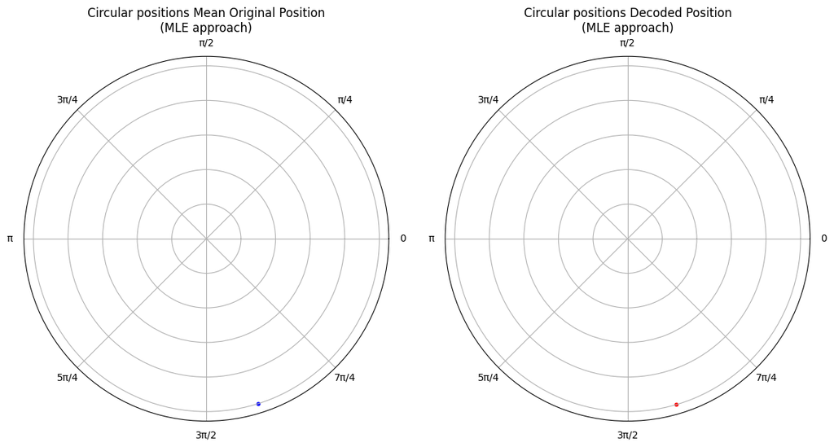

```python
test_decoded_pos_rnd_index(tw_original_positions, decoded_positions, approach_name = approach_name)
```

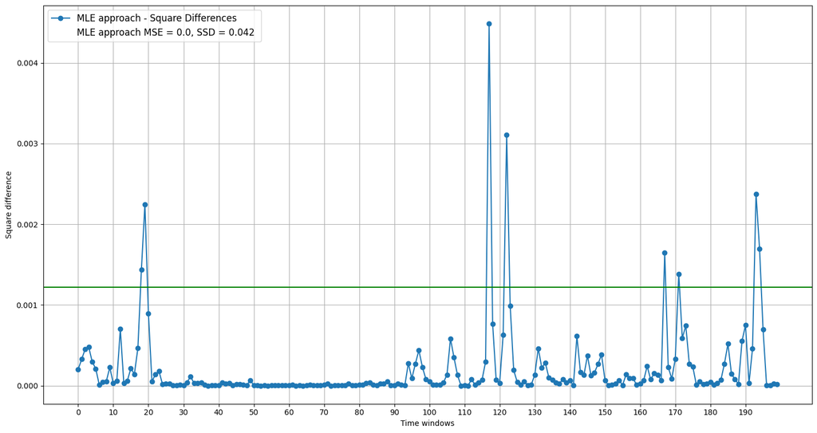

```python
mse, squared_diff = MSE_decoded_original_pos(decoded_positions, tw_original_positions)
plt_square_diff(mse, squared_diff, approach_name=approach_name, threshold_meth = 'mean_std', k=2)
```

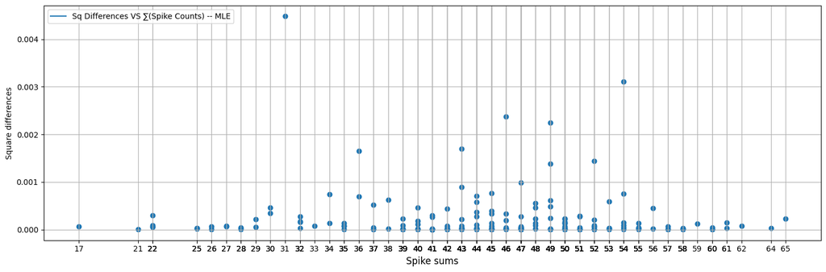

```python
# plot_spike_count_statistics_vs_squared_diff(squared_diff, spike_counts, threshold_meth = 'mean_std', k = 2)
plt_scatter_sqd_sc(spike_counts, squared_diff, approach_name)
```

[figure not shown]

```python
# plt_circular_distance(decoded_positions, tw_original_positions, approach_name)
```

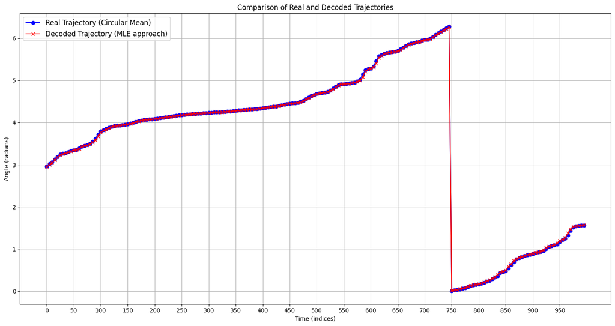

```python
plt_real_vs_decoded_trajectory(decoded_positions, tw_original_positions, approach_name, skip_ticks_step=10)
```

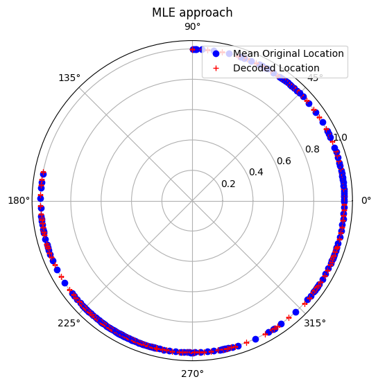

```python
plt_decoded_positions_cmp_mean_og(tw_original_positions, decoded_positions, circ_positions, sc_time_step, num_time_windows_limit=num_time_windows, tw_bounds = False, approach_name=approach_name)
```

```python
# np.eventplot -- for spike trains
```